# Food Insecurity and Health Indicators in MN Counties

Emma Holden

2025-04-12

# Introduction:

## *Background*

Food insecurity is something that affects many people all around us and in our local communities. When someone doesn’t know where their next meal is coming from, or how/if they’re going to secure that basic need, then they are experiencing food insecurity. For this project I wanted to visually map the rates of food insecurity across MN counties, to then compare these rates with diet-related health outcomes, and to look into some preventative factors for local government and outreach programs to focus on in order to help improve the health of the community at large.

## *Data*

The dataset I will be referring to in this project is from *CDC PLACES: Local Data for Better Health, County Data 2024 release.* This dataset is collected and hosted by the United States Centers for Disease Control and Prevention and is available on their website [**here**.](https://data.cdc.gov/500-Cities-Places/PLACES-Local-Data-for-Better-Health-County-Data-20/swc5-untb/data_preview)

According to the CDC, “40 of the health measures were collected by a Behavioral Risk Factor Surveillance System, the US Census decennial population survey, and Census annual county population estimates”. The Places’ website describes this data as obtained by “small-area estimation methods.” The other 9 measures are social determinants of health which were collected by the American Community Survey’s 5-year estimates.

For map data, I will be using the census tract data available through an ArcGIS application [here](https://minnesota.maps.arcgis.com/apps/webappviewer/index.html?id=cf55e729bf2a4a709dac8a97690faf62).

## *Setup*

Loading initial libraries and setting working directory for this project:

```r
setwd("C:/Users/emdho/OneDrive/Documents/DSCI 3200W/Project")
```

Initial Data Import, and creating the dataframe we will be working with (age-adjusted prevalence and filtered to just MN); Age-adjusted is recommended for health data, according to the CDC website, and I am focusing on local MN data for the immediate community impact.

```r
places <- read_csv("PLACES__Local_Data_for_Better_Health__County_Data_2024_release_20250221.csv") #cdc places dataset
places_MN_aged <- places %>%
  filter(StateAbbr=="MN"& Data_Value_Type=="Age-adjusted prevalence") #by age-adjusted prevalence

map_MN <- read_sf("cb_2023_27_tract_500k.shp") #map data
```

## *Data Dictionary*

| MeasureId | Measure |
| --- | --- |
| DIABETES | Diagnosed Diabetes among adults |
| CHD | Coronary Heart Disease among adults |
| COPD | Chronic obstructive pulmonary disease among adults |
| STROKE | Stroke among adults |
| BPHIGH | High blood pressure among adults |
| FOODINSECU | Food insecurity in the past 12 months among adults |
| FOODSTAMP | Received food stamps in the past 12 months among adults |
| CHOLSCREEN | Rate of Cholesterol Screening among adults |

## *Choosing a Preventative Measure*

Going into this project, I had already chosen food insecurity and diabetes as measures of interest, but I knew I wanted at least one preventative measure to examine for potential areas of change. Initially, I had looked at rates of recieving foodstamps, but that measure is only observed in the population of individuals already experiencing food insecurity– leading to a false-positive correlation.

To choose a different preventative measure, I created a scatterplot of food insecurity by measures labeled as ‘preventative health measures’ in the CDC dataset (CategoryID of ‘PREVENT’). I filtered the measures visually by color, and with regression lines for each. I made a second scatterplot replacing food insecurity with diabetes rates, and compared the two visualizations below:

```r
prevention<- places_MN_aged%>%
  filter(CategoryID=="PREVENT"| MeasureId=="FOODINSECU" |MeasureId=="DIABETES")%>%
  select(LocationName, Data_Value, MeasureId) #creating a new dataframe with preventative measures, food insecurity, and diabetes

testing_foodinsecu<- prevention%>%
  filter(MeasureId=="FOODINSECU")%>%
  rename("food_insecurity"= Data_Value)%>%
  select(food_insecurity, LocationName)  #renaming for clarity

testing_diabetes<- prevention%>%
  filter(MeasureId=="DIABETES")%>%
  rename("diabetes_rates"= Data_Value)%>%
  select(diabetes_rates, LocationName)

prevention<- left_join(prevention, testing_foodinsecu, by='LocationName')
prevention<- left_join(prevention, testing_diabetes, by='LocationName')

prevention<- prevention%>%
  filter(MeasureId=="ACCESS2" | MeasureId== "BPMED"|
           MeasureId=="CHECKUP" | MeasureId=="COLON_SCREEN" |
           MeasureId=="DENTAL" | MeasureId=="CHOLSCREEN" |
           MeasureId=="MAMMOUSE")
```

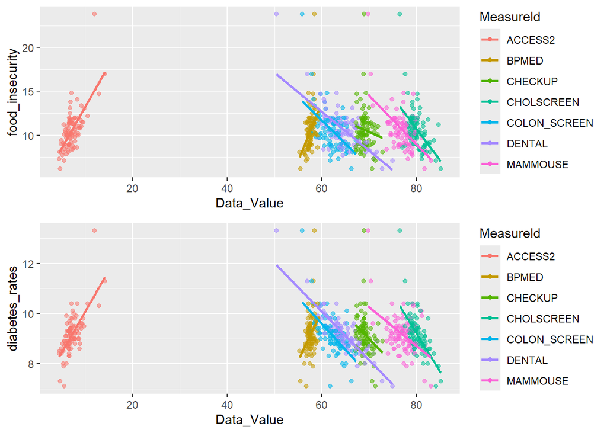

```r
gg_prev_food<- prevention%>%  #plotting food insecurity by prevention measures
  ggplot(aes(x=Data_Value, y=food_insecurity, color=MeasureId, alpha=0.2))+
  geom_point()+
  guides(alpha= "none")+
  geom_smooth(method = lm, se=FALSE)

gg_prev_diab<-  prevention%>%  #plotting diabetes by prevention measures
  ggplot(aes(x=Data_Value, y=diabetes_rates, color=MeasureId, alpha=0.2))+
  geom_point()+
  guides(alpha= "none")+
  geom_smooth(method = lm, se=FALSE)

grid.arrange(gg_prev_food, gg_prev_diab, ncol=1, nrow=2)  #arranging the two together
```

Initially I was interested in access to healthcare (ACCESSS2) due to the positive correlation, however that’s a very broad measure that encompasses a ton of issues and barriers to access. The only other positive correlation was taking blood pressure meds to reduce blood pressure (BPMED), but that could have complications later if I compared the heart health measures I was considering for a visualization. I was also interested in the negative slope of cholesterol screening, and the potential for meaningful change that could be brought by making cholesterol screening more accessible to all.

## *Data Cleaning*

The next step, after initial cleaning and deciding on my measures, was to filter the data to just these measures in wide form. I kept the original long form for later, in case I would need to refer back to it.

```r
long_places_MN_aged<- places_MN_aged%>%
  filter(MeasureId == 'DIABETES' | MeasureId == 'CHD' |
           MeasureId == 'COPD' | MeasureId == 'STROKE' |
           MeasureId == 'BPHIGH' | MeasureId == 'FOODINSECU' |
           MeasureId == 'FOODSTAMP' | MeasureId =='CHOLSCREEN')%>%   #choosing measures
  select(LocationName, TotalPop18plus, Measure, Geolocation,
         Low_Confidence_Limit, High_Confidence_Limit, Data_Value)   #kept the confidence limits in the long form, in case I wanted to make a bar graph later


wide_places_MN_aged <- long_places_MN_aged %>%
  pivot_wider(id_cols = LocationName,
              names_from = Measure,
              values_from = Data_Value)  #pivoted wider for use in analysis
```

The next step was to rename the columns back to their MeasureId’s (for convenience), I did this instead of initially selecting by MeasureId in cleaning stage, because some measures had shared ID’s (the HLTHSTAT ones) and I wanted to be very careful to avoid any potential issues from this. This way I could refer back to this code chunk instead of consulting the data dictionary too.

```r
wide_places_MN_aged <- wide_places_MN_aged%>%
  rename("COPD"=`Chronic obstructive pulmonary disease among adults`) %>%
  rename("CHD"= `Coronary heart disease among adults`) %>%
  rename("BPHIGH"= `High blood pressure among adults`)%>%
  rename("STROKE"= `Stroke among adults`)%>%
  rename("DIABETES"= `Diagnosed diabetes among adults`)%>%
  rename("FOODINSECU"= `Food insecurity in the past 12 months among adults`)%>%
  rename("CHOLSCREEN"= `Cholesterol screening among adults`)%>%
  rename("FOODSTAMP"= `Received food stamps in the past 12 months among adults`)
```

I also created a mutation in a new column for a ratio between rates of diabetes and food insecurity. I divided diabetes by food insecurity. This ratio is for later, when I compared the prevalence of these issues.

```r
wide_places_MN_aged<- wide_places_MN_aged%>% #creating mutation
  mutate(diabetes_foodinsecu_ratio=
           (DIABETES/FOODINSECU))
```

I joined the ArcGIS map data .shp file to my wide dataset into a new dataframe for later visualizations, so the dataframe map_MN is optimized for map visuals and wide_places_MN_aged is optimized for correlations.

```r
#Creating a new column in wide data table with location formatted same as .shp file
wide_places_MN_aged<- wide_places_MN_aged %>%
  mutate(NAMELSADCO =
           str_c(LocationName, " County"))  #added this string to end so that the Location Name values would be "x County" instead of "X", as NAMELSADCO in .shp file includes " County" after each county name

map_MN<- left_join(map_MN, wide_places_MN_aged, by='NAMELSADCO') #joining back by location

adult_pop_df<- places_MN_aged%>%
  mutate(NAMELSADCO = str_c(LocationName, " County"))%>%
    select(NAMELSADCO, TotalPop18plus)
#adding a column for adult population for later reference

map_MN<- left_join(map_MN, adult_pop_df, by='NAMELSADCO') #joining by location
```

# Visualizations:

So, the first thing I wanted to look at was these heart health indicators and how they were correlated to food insecurity, namely if there was a relationship worth examining for this project overall.

## *Initial Heart Health Scatterplots*

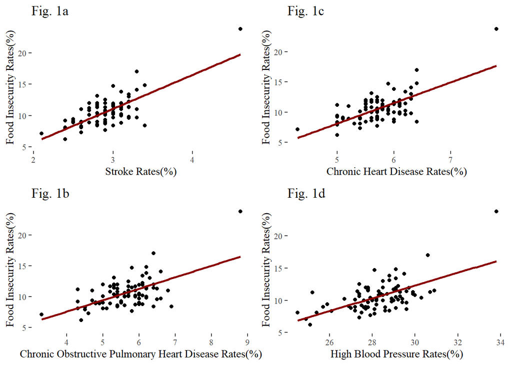

```r
#heart health

#scatterplot for stroke rates
gg_stroke<-   #named to call on later
  wide_places_MN_aged %>%
  ggplot(aes(x=STROKE, y=FOODINSECU))+  #choosing variables
  geom_point()+
  geom_smooth(method=lm, color= "dark red", alpha=0)+   #red regression line (red will be for heart health from here on in this project)
  theme(legend.position = "right")+
  theme_tufte() + #I liked this theme :]
  labs(x="Stroke Rates(%)",
       y="Food Insecurity Rates(%)",
       title="Fig. 1a")  #labels for axes

#scatterplot for chronic obstructive pulmonary disease rates
gg_copd<-
  wide_places_MN_aged %>%
  ggplot(aes(x=COPD, y=FOODINSECU))+
  geom_point()+
  geom_smooth(method=lm, color= "dark red", alpha=0)+
  theme(legend.position = "right")+
  theme_tufte()+
  labs(x="Chronic Obstructive Pulmonary Heart Disease Rates(%)",
       y="Food Insecurity Rates(%)",
       title="Fig. 1b")


#scatterplot for Chronic heart disease
gg_chd<-
  wide_places_MN_aged %>%
  ggplot(aes(x=CHD, y=FOODINSECU))+
  geom_point()+
  geom_smooth(method=lm, color= "dark red", alpha=0)+
  theme(legend.position = "right")+
  theme_tufte()+
  labs(x="Chronic Heart Disease Rates(%)",
       y="Food Insecurity Rates(%)",
       title="Fig. 1c")

#scatterplot for reported high blood pressure
gg_bp<-
  wide_places_MN_aged %>%
  ggplot(aes(x=BPHIGH, y=FOODINSECU))+
  geom_point()+
  geom_smooth(method=lm, color= "dark red", alpha=0)+
  theme(legend.position = "right")+
  theme_tufte() +
  labs(x="High Blood Pressure Rates(%)",
       y="Food Insecurity Rates(%)",
       title="Fig. 1d")
grid.arrange(gg_stroke, gg_chd, gg_copd, gg_bp, ncol=2, nrow =2) #arranged in a column to compare all 4
```

All four of these measures showed positive correlations to food insecurity rates. I ran a Pearson’s correlation matrix later to check, and confirmed findings.

## *Initial Maps*

### *Adult Population:*

For reference while looking at the following maps, and to practice map-making with the joined dataset, I first made a map of MN Adult Population by county:

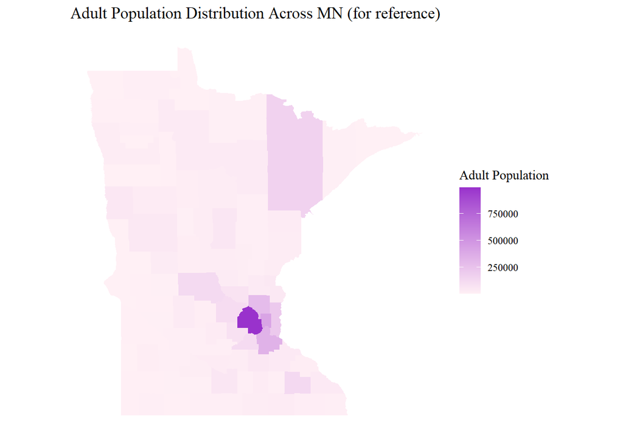

```r
ggplot(map_MN)+
  geom_sf(color="transparent")+    #hiding lines of census tracts, we only want the counties by fill color
  theme_tufte()+     #I liked this theme :]
  scale_fill_gradient(low="lavenderblush", high="darkorchid")+   #darker purple is higher pop density, lighter is lower, this was practice for fill by color gradient
  aes(fill=TotalPop18plus)+   #filling by adult population
  labs(title = "Adult Population Distribution Across MN (for reference)",
       fill="Adult Population")+   #labeling map
  theme(legend.position = "right",
    axis.text = element_blank(),  #hiding long and lat coords because not needed for this type of map visualization
    axis.title = element_blank(),
    axis.ticks = element_blank())
```

### *Heart Health:*

I then applied this framework for a map of MN counties to the previous heart-health measures, in order to compare their rates visually.

```r
gg_map_stroke_2<- ggplot(map_MN)+
  geom_sf(color="transparent")+  #hiding outlines (census tract lines in .shp file)
  theme_tufte()+
  scale_fill_gradient(low="lightyellow", high="darkred")+
  aes(fill=STROKE)+
  labs(title = "Fig. 2a: Stroke Rates in MN Counties",
       fill="% of Adults Diagnosed")+
  theme(legend.position = "left",
    axis.text = element_blank(),
    axis.title = element_blank(),
    axis.ticks = element_blank())

gg_map_copd_2<- ggplot(map_MN)+
  geom_sf(color="transparent")+
  theme_tufte()+
  scale_fill_gradient(low="lightyellow", high="darkred")+
  aes(fill=COPD)+
  labs(title = "Fig. 2b: Chronic Obstructive Pulmonary Disease Rates",
       fill="% of Adults Diagnosed")+
  theme(legend.position = "left",
    axis.text = element_blank(),
    axis.title = element_blank(),
    axis.ticks = element_blank())

gg_map_chd_2<- ggplot(map_MN)+
  geom_sf(color="transparent")+
  theme_tufte()+
  scale_fill_gradient(low="lightyellow", high="darkred")+
  aes(fill=CHD)+
  labs(title = "Fig. 2c: Coronary Heart Disease",
       fill="% of Adults Diagnosed")+
  theme(legend.position = "right",
    axis.text = element_blank(),
    axis.title = element_blank(),
    axis.ticks = element_blank())


gg_map_bp_2<- ggplot(map_MN)+
  geom_sf(color="transparent")+
  theme_tufte()+
  scale_fill_gradient(low="lightyellow", high="darkred")+
  aes(fill=BPHIGH)+
  labs(title = "Fig. 2d: High Blood Pressure Rates",
       fill="% of Adults Reporting")+
  theme(legend.position = "right",
    axis.text = element_blank(),
    axis.title = element_blank(),
    axis.ticks = element_blank())
```

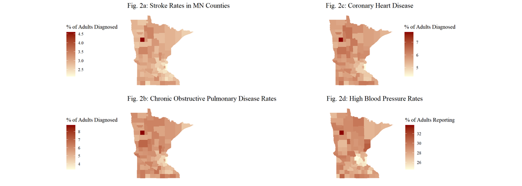

```r
grid.arrange(gg_map_stroke_2, gg_map_chd_2, gg_map_copd_2, gg_map_bp_2, ncol=2, nrow =2)
```

```r
#similar grid arranging, in diff. chunk so that fig.width can be set wider to prevent overlap of labels
```

### *Food Insecurity:*

I then wanted to compare them to the initial measure of food insecurity once more, this time in its own map.

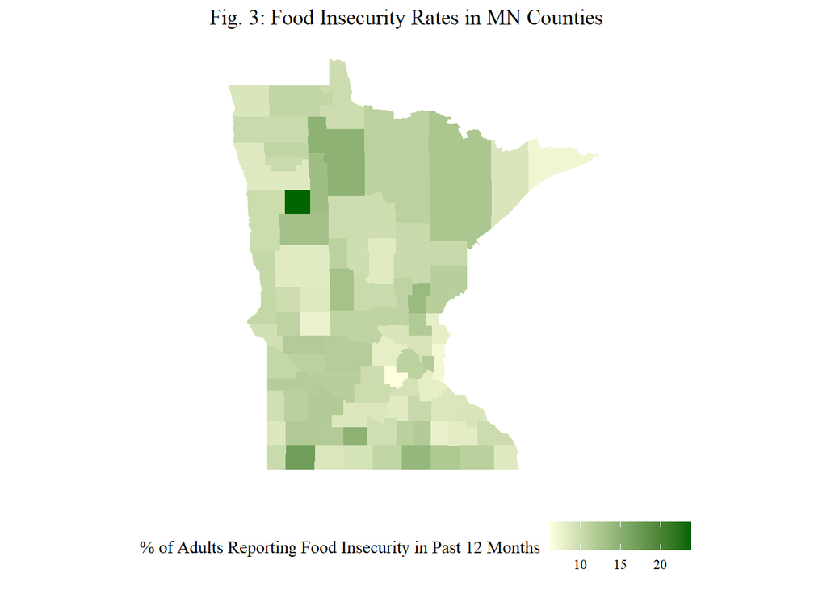

```r
#map of food insecurity
gg_foodinsecu<- ggplot(map_MN)+ #named to environment so we can call it up later to compare to other maps
  geom_sf(color="transparent")+
  theme_tufte()+
  scale_fill_gradient(low="lightyellow", high="darkgreen")+  #darker green is higher rate of reported foodinsecurity in the past 12 months
  aes(fill=FOODINSECU)+ #choosing var. (foodinsecurity)
  labs(title = "Fig. 3: Food Insecurity Rates in MN Counties",
       fill="% of Adults Reporting Food Insecurity in Past 12 Months")+
  theme(legend.position = "bottom",
    axis.text = element_blank(),
    axis.title = element_blank(),
    axis.ticks = element_blank())
gg_foodinsecu #showing the map we just made
```

Food insecurity is filled in green this time, and will continue to be for the duration of this project. Darker green indicates higher rates of food insecurity, and lighter green indicates lower rates.

The same correlations demonstrated in our earlier scatterplots are visually evident in these maps’ similar color saturations. There are some differences, sure, but the trend is overall positive.

### *Diabetes:*

This is the case too, with the following diabetes map:

```r
#map of diabetes
gg_diabetes<- ggplot(map_MN)+ #also naming to keep in our environment for later
  geom_sf(color="transparent")+ #hiding the lines for census tracts
  theme_tufte()+
  scale_fill_gradient(low="lightyellow", high="darkblue")+ #darker blue is higher rate of diabetes
  aes(fill=DIABETES)+
  labs(title = "Fig. 4: Diabetes Rates in MN Counties",
       fill="% of Adults Diagnosed with Diabetes")+
  theme(legend.position = "bottom",
    axis.text = element_blank(),
    axis.title = element_blank(),
    axis.ticks = element_blank())
#not calling this one to show itself immediately though, instead we're arranging it in a grid with the prior food insecurity one:
```

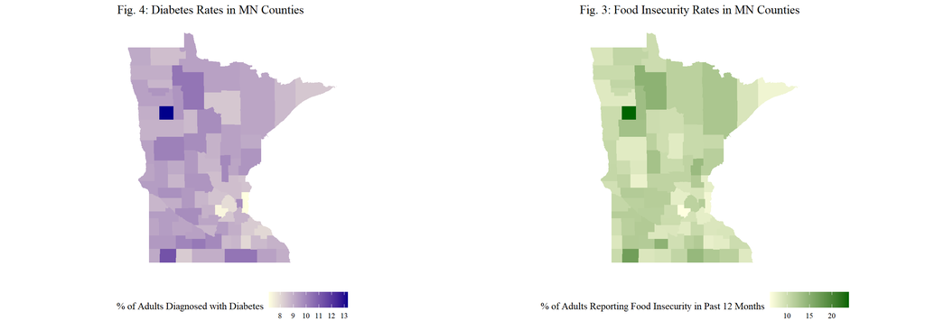

```r
grid.arrange(gg_diabetes, gg_foodinsecu, ncol=2, nrow =1)
```

```r
#arranged in seperate chunk for fig.width to prevent label overlap
```

I aranged the map of diabetes, (filled in dark blue, as it will continue to be), next to the food insecurity map to compare. The maps appear visually similar, but to double check for a positive correlation, I made another scatterplot between the two of them. I also ran a pearson’s correlation test later, and confirmed this relationship.

## *Diabetes**/Food Insecurity Scatterplot:*

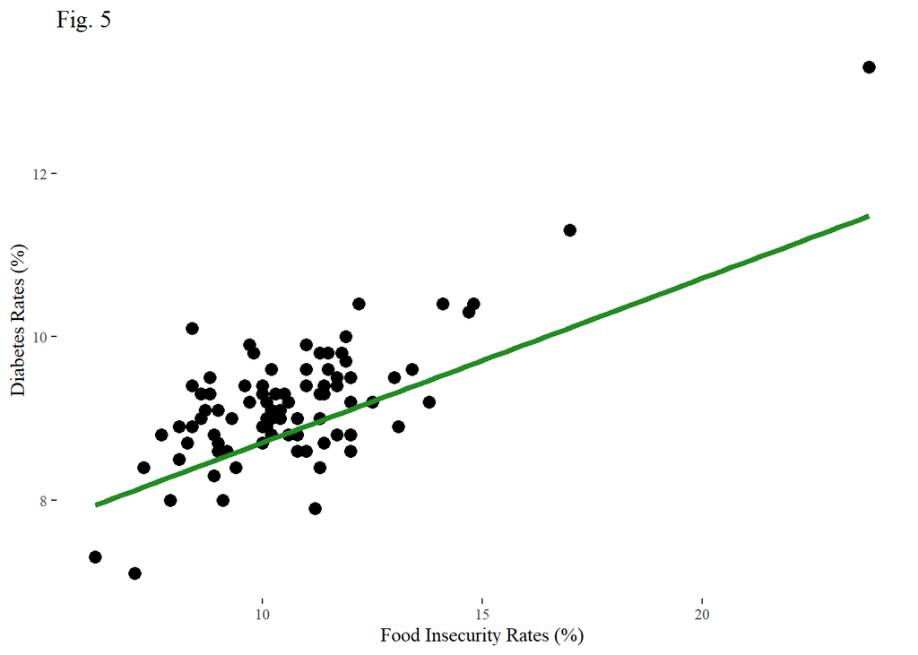

```r
gg_insecu_diabetes<-map_MN %>%
  ggplot(aes(y=DIABETES, x=FOODINSECU))+ #Comparing diabetes and food insecurity variables
  geom_point(size=3)+  #Was having issues with points being too big, so I set them to 3.
  theme(legend.position = "right")+
  theme_tufte() + #I like this theme, but at this point I was starting to regret my choice to use it. It takes much longer to load than minimal. Ultimately, it proved worth the wait.
  labs(y= "Diabetes Rates (%)",
       x= "Food Insecurity Rates (%)",
       title= "Fig. 5")+
  geom_smooth(method=lm, color= "forestgreen", se=FALSE, size=1.5) #Regression line set to 1.5 width, in green.
gg_insecu_diabetes #also naming this one for later (spoiler warning!)
```

After establishing positive correlations between Food Insecurity and all of these health measures, I wanted to examine which Counties are most affected by these issues.

## *Critical Areas*

### *Critical Tables:*

```r
#table of highest food-insecure rated counties
most_food_insecu<- wide_places_MN_aged%>%  #Naming for later
  arrange(desc(FOODINSECU))%>% #arranged by descending
  select(NAMELSADCO, FOODINSECU)%>%
  rename("County"=NAMELSADCO)%>%  #Renaming to be more descriptive for the table.
  rename("Rate of Adults reporting Food Insecurity"=FOODINSECU)%>% #also more descriptive
  head(most_food_insecu, n=5)  #Give us the top 5 only

#table of highest diabetes counties
most_diabetes<- wide_places_MN_aged%>%  #similar to above
  arrange(desc(DIABETES))%>%
  select(NAMELSADCO, DIABETES)%>%
  rename("County"=NAMELSADCO)%>%
  rename("Rate of Adults with Diagnosed Diabetes"=DIABETES)%>%
  head(most_diabetes, n=5)

#didn't just arrange the map file because it contains duplicate values due to each census tract holding the value for that county for mapping purposes

#Ended up using kableExtra library with kable_styling function to have these tables line up next to each other
most_food_insecu %>%
  kable("html", align = 'clc', caption = 'test')%>%
  kable_styling(full_width = F, position = "float_left")
```

| County | Rate of Adults reporting Food Insecurity |
| --- | --- |
| Mahnomen County | 23.8 |
| Nobles County | 17.0 |
| Beltrami County | 14.8 |
| Watonwan County | 14.7 |
| Freeborn County | 14.1 |

```r
most_diabetes %>%
  kable("html", align = 'clc', caption = 'test') %>%
  kable_styling(full_width = F, position = "right")
```

| County | Rate of Adults with Diagnosed Diabetes |
| --- | --- |
| Mahnomen County | 13.3 |
| Nobles County | 11.3 |
| Beltrami County | 10.4 |
| Freeborn County | 10.4 |
| Mower County | 10.4 |

### *Critical Maps:*

To visualize where these counties are located, and compare them back to the initial map, I created new maps highlighting just these counties.

First, I joined these tables back to my map dataframe, ranked as most to fifth-most of their respective rates.

```r
#joining back to map data
most_diabetes<- most_diabetes%>%
  rename("NAMELSADCO"= County)%>%
  rename("top_5_diabetes"= `Rate of Adults with Diagnosed Diabetes`) #renaming for readability

map_MN<- left_join(map_MN, most_diabetes, by= 'NAMELSADCO') #joining back by location

most_food_insecu<- most_food_insecu%>%
  rename("NAMELSADCO"= County)%>%
  rename("top_5_foodinsecu"= `Rate of Adults reporting Food Insecurity`) #renaming

map_MN<- left_join(map_MN, most_food_insecu, by= 'NAMELSADCO') #joining

shape_most_diabetes<- map_MN %>%
  filter(!is.na(top_5_diabetes)) %>%
  group_by(LocationName) %>%
  summarise(top_5_diabetes = first(top_5_diabetes))  #creating .shp compatible dataframe for top diabetes

shape_most_foodinsecu<- map_MN %>%
  filter(!is.na(top_5_foodinsecu)) %>%
  group_by(LocationName) %>%
  summarise(top_5_foodinsecu = first(top_5_foodinsecu))  #creating .shp compatible dataframe for top food insecurity
```

I then rendered the maps with these top 5 counties against a grey background.

```r
#visuals placed in a separate chunk for easy modifications

gg_most_diabetes <- ggplot(map_MN) +
  geom_sf(aes(fill = top_5_diabetes), color = "transparent") +
  geom_sf_text(data = shape_most_diabetes, aes(label = LocationName),  #labeling counties
               size = 1.5, color = "white") +  #it was hard to find a label that was visible, not too small, didn't overlap, and didn't erase other labels if overlapping was turned off.
  theme_tufte() +
  scale_fill_gradient(low="blue", high="darkblue", na.value="darkgrey")+ #darker blue is highest rates of diabetes, grey is areas not in top 5
  labs(title = "Fig. 6a: Highest Overall Diabetes Rates")+
  theme(legend.position = "none",
    axis.text = element_blank(),
    axis.title = element_blank(),
    axis.ticks = element_blank(),
    panel.background= element_rect(fill = "transparent", color = NA)) #experimenting with transparent background




gg_most_foodinsecu <- ggplot(map_MN) +
  geom_sf(aes(fill = top_5_foodinsecu), color = "transparent") +
  geom_sf_text(data = shape_most_foodinsecu, aes(label = LocationName),
               size = 1.5, color = "white") +
  theme_tufte() +
  scale_fill_gradient(low="forestgreen", high="darkgreen", na.value="darkgrey")+
  #same as above map, however this time dark green is highest rates of food insecurity and grey is areas not in top 5
  labs(title = "Fig. 6b: Highest Overall Food Insecurity Rates")+
  theme(legend.position = "none",
    axis.text = element_blank(),
    axis.title = element_blank(),
    axis.ticks = element_blank(),
    panel.background = element_rect(fill = "transparent", color = NA))
```

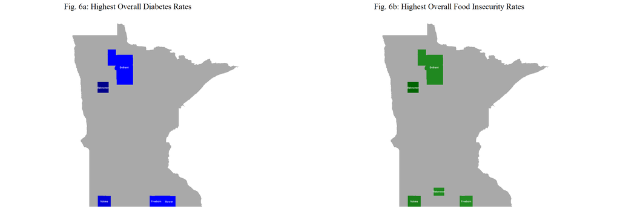

```r
grid.arrange(gg_most_diabetes, gg_most_foodinsecu, ncol=2, nrow=1)  #ok, now show us the two together
```

## *Visualizing the Ratio Mutation*

Referring back to the Ratio mutation made during initial data cleaning, I wanted to visualize this on a map. I set light green as the lowest ratio (the most food insecurity proportionate to diabetes), and dark blue as the highest ratio (the most diabetes proportionate to food insecurity). Mahnomen county was notable as it had the highest rate of food insecurity proportionate to diabetes, but also the highest of both of those measures overall.

### *Ratio Map:*

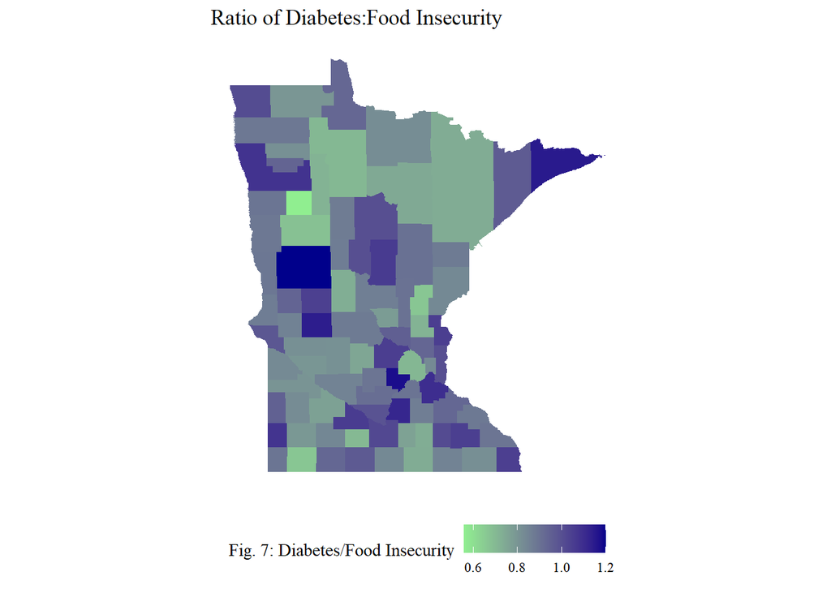

```r
gg_ratio<- ggplot(map_MN)+
  geom_sf(color="transparent")+
  theme_tufte()+
  scale_fill_gradient(low="lightgreen", high="darkblue")+
  aes(fill=diabetes_foodinsecu_ratio)+
  labs(title = "Ratio of Diabetes:Food Insecurity",
       fill="Fig. 7: Diabetes/Food Insecurity")+
  theme(legend.position = "bottom",
    axis.text = element_blank(),
    axis.title = element_blank(),
    axis.ticks = element_blank())

gg_ratio
```

### *Summary Stats:*

Another visual representation of the skew of the above distribution is with a summary, which shows that the minimum (or point where there’s the most food insecurity compared to diabetes) is much further from the point of these rates being equal (1), than the maximum (or point where there’s the most diabetes compared to food insecurity). This also shows that the Median, Mean, and even 3rd quartile are all under 1; ie. there’s more food insecurity overall than there is diabetes in MN counties.

```r
summary(wide_places_MN_aged$diabetes_foodinsecu_ratio) #summary is filtered to just be for this ratio in the wide places dataset
```

```
##    Min. 1st Qu.  Median    Mean 3rd Qu.    Max.
##  0.5588  0.8077  0.8791  0.8888  0.9735  1.2024
```

## *Protective Factors*

### *Foodstamps:*

Initially, I tried comparing foodstamps as a protective factor. I hypothesized that foodstamps would decrease food insecurity, and possibly show a decrease in diabetes. However, this hypothesis proved to be unsuitable for the dataset due to foodstamp eligibility being dependent on food insecurity. I visualized the relationships between foodstamps and food insecurity, and between foodstamps and diabetes, and noted this false-positive relationship.

```r
gg_stamp_foodinsecu<- map_MN%>%
  ggplot(aes(x = FOODSTAMP, y=FOODINSECU)) +
  geom_point(color="darkgreen", size=3)+
  theme_tufte()+
  geom_smooth(method=lm, se=FALSE, color="lightgreen", size=2)

gg_stamp_diabetes<- map_MN%>%
  ggplot(aes(x = FOODSTAMP, y=DIABETES)) +
  geom_point(color="darkblue", size=3)+
  theme_tufte()+
  geom_smooth(method=lm, se=FALSE, color="skyblue", size=2)
```

I took a closer look at the foodstamp/diabetes correlation and the food insecurity/diabetes correlation to compare:

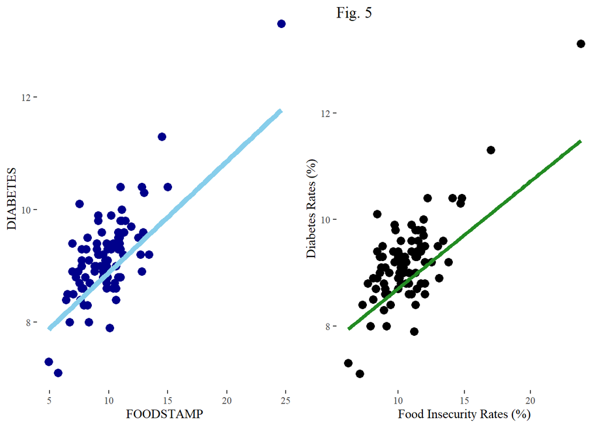

```r
grid.arrange(gg_stamp_diabetes, gg_insecu_diabetes, ncol=2, nrow=1)
```

They appear as nearly the same line.

### *Cholesterol Screening:*

Luckily, I also had chosen cholesterol screening rates from preventative health measures as a potential protective factor. I made the following visualizations examining the relationships between cholesterol screening rates (CHOLSCREEN) and our focus measures of diabetes and food insecurity.

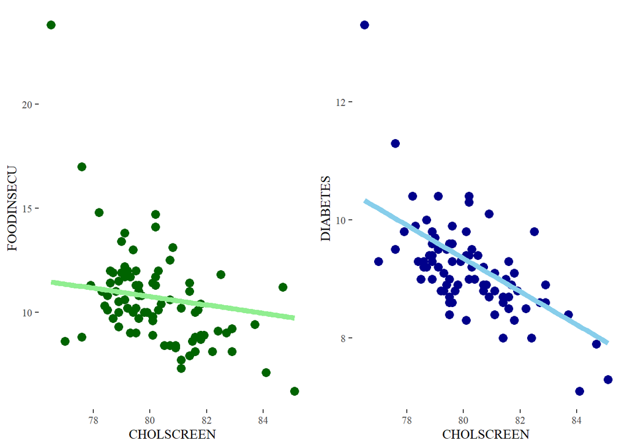

```r
gg_chol_foodinsecu<- map_MN%>%
  ggplot(aes(x = CHOLSCREEN, y=FOODINSECU)) +
  geom_point(color="darkgreen", size=3)+
  theme_tufte()+
  geom_smooth(method=lm, se=FALSE, color="lightgreen", size=2)

gg_chol_diabetes<- map_MN%>%
  ggplot(aes(x = CHOLSCREEN, y=DIABETES)) +
  geom_point(color="darkblue", size=3)+
  theme_tufte()+
  geom_smooth(method=lm, se=FALSE, color="skyblue", size=2)


grid.arrange(gg_chol_foodinsecu, gg_chol_diabetes, ncol=2, nrow=1)
```

The correlations between cholesterol screening and food insecurity and between cholesterol screening and diabetes are both negative, with a stronger correlation between diabetes and cholesterol screening.

## *Correlation Matrixes*

### *Cholesterol Screening:*

I ran a correlation matrix below to see how strong those relationships truly are:

```r
chol_matrix <- cor(wide_places_MN_aged[, c("FOODINSECU", "DIABETES" ,"CHOLSCREEN")])
print(chol_matrix)
```

```
##            FOODINSECU   DIABETES CHOLSCREEN
## FOODINSECU  1.0000000  0.7614944 -0.5087722
## DIABETES    0.7614944  1.0000000 -0.6376477
## CHOLSCREEN -0.5087722 -0.6376477  1.0000000
```

```r
cor.test(wide_places_MN_aged$FOODINSECU, wide_places_MN_aged$DIABETES)
```

```
##
##  Pearson's product-moment correlation
##
## data:  wide_places_MN_aged$FOODINSECU and wide_places_MN_aged$DIABETES
## t = 10.831, df = 85, p-value < 2.2e-16
## alternative hypothesis: true correlation is not equal to 0
## 95 percent confidence interval:
##  0.6560874 0.8377597
## sample estimates:
##       cor
## 0.7614944
```

```r
cor.test(wide_places_MN_aged$FOODINSECU, wide_places_MN_aged$CHOLSCREEN)
```

```
##
##  Pearson's product-moment correlation
##
## data:  wide_places_MN_aged$FOODINSECU and wide_places_MN_aged$CHOLSCREEN
## t = -5.4485, df = 85, p-value = 4.866e-07
## alternative hypothesis: true correlation is not equal to 0
## 95 percent confidence interval:
##  -0.6497820 -0.3339097
## sample estimates:
##        cor
## -0.5087722
```

```r
cor.test(wide_places_MN_aged$DIABETES, wide_places_MN_aged$CHOLSCREEN)
```

```
##
##  Pearson's product-moment correlation
##
## data:  wide_places_MN_aged$DIABETES and wide_places_MN_aged$CHOLSCREEN
## t = -7.6316, df = 85, p-value = 3.103e-11
## alternative hypothesis: true correlation is not equal to 0
## 95 percent confidence interval:
##  -0.7478458 -0.4932529
## sample estimates:
##        cor
## -0.6376477
```

We can see those are signficant correlations.

### *Heart-Health* *Measures:*

I also ran a matrix with the earlier heart-health measures.

```r
heart_matrix <- cor(wide_places_MN_aged[, c("FOODINSECU", "CHD" , "COPD", "STROKE", "BPHIGH", "CHOLSCREEN")])
print(heart_matrix)
```

```
##            FOODINSECU        CHD       COPD     STROKE     BPHIGH CHOLSCREEN
## FOODINSECU  1.0000000  0.6733373  0.5885385  0.7222472  0.6070106 -0.5087722
## CHD         0.6733373  1.0000000  0.9586196  0.9665453  0.7080932 -0.6999569
## COPD        0.5885385  0.9586196  1.0000000  0.9512878  0.6495663 -0.6725884
## STROKE      0.7222472  0.9665453  0.9512878  1.0000000  0.6828478 -0.6568249
## BPHIGH      0.6070106  0.7080932  0.6495663  0.6828478  1.0000000 -0.7128375
## CHOLSCREEN -0.5087722 -0.6999569 -0.6725884 -0.6568249 -0.7128375  1.0000000
```

# Conclusion and Recommendations

Based on this project, I would make the following recommendations:

> Increase accessibility to cholesterol screening. More research is recommended into why counties may have lower rates of cholesterol screening, and how it specifically relates (is it health access by income? is it diet-choices, made difficult by food insecurity? Does simple awareness have an impact without any other preventative factors? Either way, access would benefit community health).

> Further research into relationship between diabetes and food insecurity. Does providing food insecurity support lower rates of diabetes in MN counties? Does providing diabetes support decrease rates of food insecurity? What are the counties with the lowest rates of these things doing to maintain these low rates?

> As individuals, we can volunteer with local community organizations to help others in our community have better access to nutritional food.

> As organized community, we can target aid programs to counties that experience the highest rates of food insecurity for more immediate support.

This brings us to our last point…

## *What’s the deal with Mahnomen County?*

Earlier, we noted that Mahnomen County has abnormally high food insecurity and diabetes rates. I wanted to see if this was an issue with the data, or a genuine problem faced by the people living there. First, I went back to my initial data cleaning and checked to see if it was an error in the age-adjusted values. I tested the crude data from the initial places dataset, for top 5 highest diabetes rates and food insecurity rates in order to see if Mahnomen was an outlier there as well.

In the crude dataset, Mahnomen County also has the highest rates of these variables.

```r
crude_test <- places %>%
  filter(StateAbbr=="MN"& Data_Value_Type=="Crude prevalence") #creating crude dataframe

long_crude<- crude_test%>%
  filter(MeasureId == 'DIABETES' | MeasureId == 'CHD' |
           MeasureId == 'COPD' | MeasureId == 'STROKE' |
           MeasureId == 'BPHIGH' | MeasureId == 'FOODINSECU' |
           MeasureId == 'FOODSTAMP' | MeasureId =='CHOLSCREEN')%>%
  select(LocationName, TotalPop18plus, Measure, Geolocation,
         Low_Confidence_Limit, High_Confidence_Limit, Data_Value)


wide_crude <- long_crude %>%
  pivot_wider(id_cols = LocationName,
              names_from = Measure,
              values_from = Data_Value)

wide_crude%>%
  arrange(desc(`Food insecurity in the past 12 months among adults`))%>%
  select(`Food insecurity in the past 12 months among adults`, LocationName)%>%
  head(5)  #getting highest food insecu rates
```

```
## # A tibble: 5 × 2
##   `Food insecurity in the past 12 months among adults` LocationName
##                                                  <dbl> <chr>
## 1                                                 22.7 Mahnomen
## 2                                                 16   Nobles
## 3                                                 13.4 Beltrami
## 4                                                 13.3 Watonwan
## 5                                                 12.7 Kanabec
```

```r
wide_crude%>%
  arrange(desc(`Diagnosed diabetes among adults`))%>%
  select(`Diagnosed diabetes among adults`, LocationName)%>%
  head(5) #getting highest diabetes rates
```

```
## # A tibble: 5 × 2
##   `Diagnosed diabetes among adults` LocationName
##                               <dbl> <chr>
## 1                              15.6 Mahnomen
## 2                              14.1 Aitkin
## 3                              13.9 Otter Tail
## 4                              13.6 Cass
## 5                              13.5 Big Stone
```

I did some further research, comparing to the national average, and then comparing to the difference betwen Mahnomen County’s rate and the MN state average. Findings indicated that even compared to these averages, Mahnomen County’s rates of 23.8% of adults reporting food insecurity and 13.3% of adults diagnosed with diabetes are high:

```r
state_avg<- places%>%
  filter(Data_Value_Type=="Age-adjusted prevalence")%>%
  filter(StateAbbr=="MN")%>%
  filter(MeasureId=="DIABETES" | MeasureId=="FOODINSECU")%>%
  select(MeasureId, Data_Value)  #finding state avg

state_avg%>%
group_by(MeasureId)%>%
  rename("state_avg"=Data_Value)%>%
  summarise(mean(state_avg)) #summarizing and renaming for table
```

```
## # A tibble: 2 × 2
##   MeasureId  `mean(state_avg)`
##   <chr>                  <dbl>
## 1 DIABETES                9.16
## 2 FOODINSECU             10.6
```

```r
nat_avg<- places%>%
  filter(Data_Value_Type=="Age-adjusted prevalence")%>%
  filter(MeasureId=="DIABETES" | MeasureId=="FOODINSECU")%>%
  select(MeasureId, Data_Value) #finding national avg

nat_avg%>%
group_by(MeasureId)%>%
  rename("us_avg"=Data_Value)%>%
  summarise(mean(us_avg)) #summarizing and renaming for table
```

```
## # A tibble: 2 × 2
##   MeasureId  `mean(us_avg)`
##   <chr>               <dbl>
## 1 DIABETES             11.1
## 2 FOODINSECU           16.4
```

I questioned whether the CDC Places dataset could have been erroneous, and found a secondary source. According to the data over at [Feeding America](https://map.feedingamerica.org/county/2021/overall/minnesota/county/mahnomen), Mahnomen county only had a food insecurity rate of 13% in 2021, which, also according to them, is still the highest in the state.

Instead focusing my research on the location itself, I found that Mahnomen county is entirely encompassed by Gaa-Waabaabiganikaag, or White Earth Nation, which also extends partially into Clearwater and Becker counties. [It is the only county in MN entirely encapsulated by a Native American reservation, although not the only First Nations community in MN.](https://mn.gov/indian-affairs/tribal-nations-in-minnesota/gaa-waabaabiganikaag-white-earth-nation.jsp)

Given this additional perspective I would also recommend further research into the rates of food insecurity in Native American reservations here in MN, as well as reaching out to food shelves and local community organizers in these areas in order to gain a better understanding of the factors that may be contributing to this rate.

# Works Cited

Centers for Disease Control and Prevention. (2024, August 16). Age adjustment - health, United States. Centers for Disease Control and Prevention. https://www.cdc.gov/nchs/hus/sources-definitions/age-adjustment.htm

Centers for Disease Control and Prevention. (n.d.). Places: Local data for better health, County Data 2024 release. Centers for Disease Control and Prevention. https://data.cdc.gov/500-Cities-Places/PLACES-Local-Data-for-Better-Health-County-Data-20/swc5-untb/data_preview

MN.gov. (n.d.). 2020 Census Population and Housing Units. ArcGIS web application. https://minnesota.maps.arcgis.com/apps/webappviewer/index.html?id=cf55e729bf2a4a709dac8a97690faf62

Minnesota Indian Affairs Council . (2024, January 17). Gaa-waabaabiganikaag / White Earth Nation . MN.gov. https://mn.gov/indian-affairs/tribal-nations-in-minnesota/gaa-waabaabiganikaag-white-earth-nation.jsp